# 데이터 시각화 예제

# TAAS 교통사고 분석시스템 인포그래픽 따라하기

(http://taas.koroad.or.kr/sta/acs/gus/selectStaInfoGraph.do?menuId=WEB_KMP_IDA_TAI)

[figure not shown]

2018-2020년 대전교통사고 자료를 이용하여 위 그림의 ’교통사고 일반특성’를 구해보겠습니다.

배웠던 내용을 복습하면서 인포그래픽스를 살펴보겠습니다.

## 교통사고 통계

[figure not shown]

```r
library(readxl)
data1 <- read_excel("대전광역시_대덕구.xlsx")
data2 <- read_excel("대전광역시_동구.xlsx")
data3 <- read_excel("대전광역시_서구.xlsx")
data4 <- read_excel("대전광역시_서구2.xlsx")
data5 <- read_excel("대전광역시_중구.xlsx")

t.data1 <- rbind(data1, data2, data3, data4, data5)
```

2018-2020년 대전광역시 교통사고 건수 : 17205

```r
nrow(t.data1)
```

```
## [1] 17205
```

2018-2020년 대전광역시 사망자수 : 178

```r
sum(t.data1$사망자수)
```

```
## [1] 178
```

2018-2020년 대전광역시 요일별 교통사고 건수 및 비율

```r
library(dplyr)
table(t.data1$요일) %>%
  data.frame %>%
  arrange(desc(Freq))
```

```
##     Var1 Freq
## 1 금요일 2848
## 2 월요일 2601
## 3 목요일 2535
## 4 토요일 2501
## 5 수요일 2443
## 6 화요일 2404
## 7 일요일 1873
```

```r
round(table(t.data1$요일)/sum(table(t.data1$요일))*100,2)%>%
  data.frame
```

```
##     Var1  Freq
## 1 금요일 16.55
## 2 목요일 14.73
## 3 수요일 14.20
## 4 월요일 15.12
## 5 일요일 10.89
## 6 토요일 14.54
## 7 화요일 13.97
```

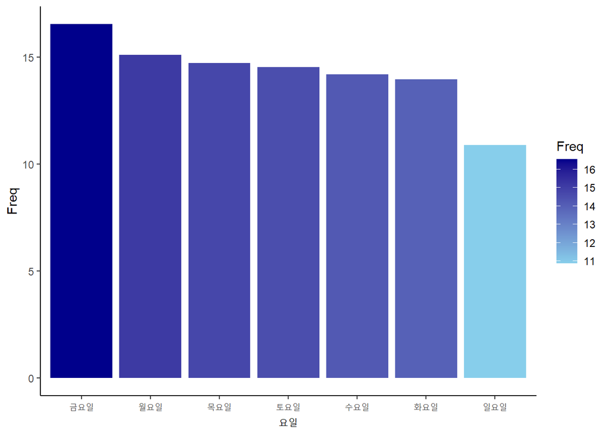

```r
library(ggplot2)
round(table(t.data1$요일)/sum(table(t.data1$요일))*100,2)%>%
  data.frame %>%
  arrange(desc(Freq)) %>% ggplot(aes(reorder(x=Var1, -Freq), y=Freq, fill=Freq))+
  geom_bar(stat="identity")+
  scale_fill_gradient(low="skyblue",high="darkblue")+
  xlab("요일")+
  theme_classic()
```

이 외에 인적(가해운전자.연령, 법규위반), 차량(가해운전자.차종), 도로(도로형태)의 빈도분석

## 교통사고 현황

[figure not shown]

요일별 사고

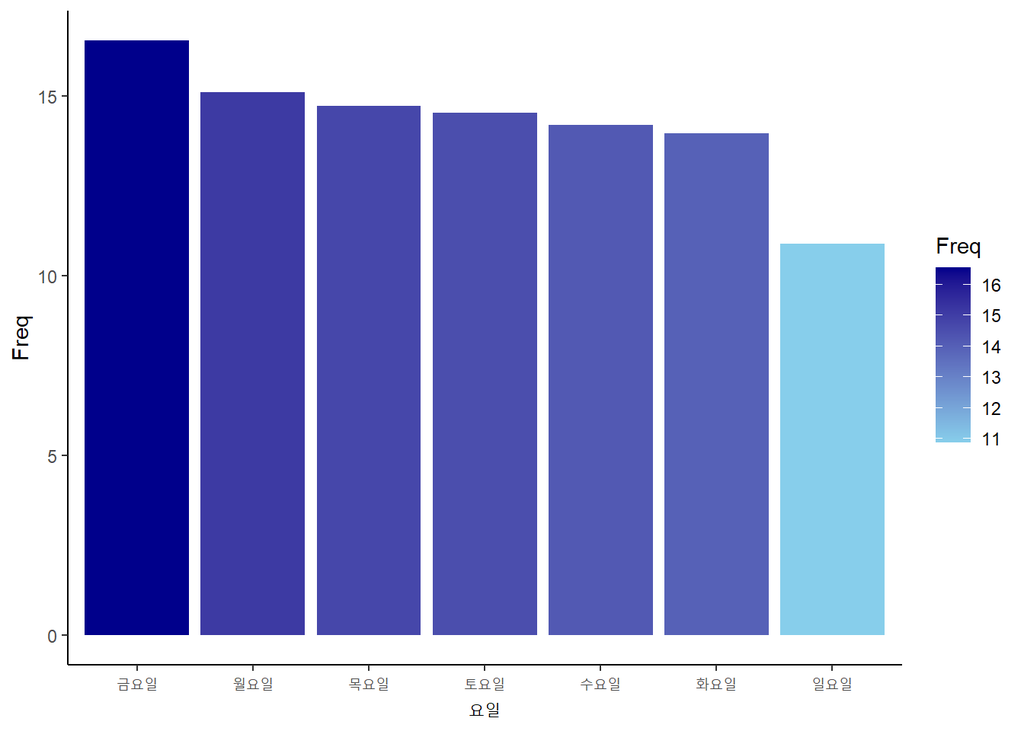

```r
library(ggplot2)
round(table(t.data1$요일)/sum(table(t.data1$요일))*100,2)%>%
  data.frame %>%
  arrange(desc(Freq)) %>% ggplot(aes(reorder(x=Var1, -Freq), y=Freq, fill=Freq))+
  geom_bar(stat="identity")+
  scale_fill_gradient(low="skyblue",high="darkblue")+
  xlab("요일")+
  theme_classic()
```

금요일만 생각이 들어가도록 ifelse 설정

요일은 자동으로 정렬되므로 factor 함수를 이용하여 원하는 순서로 고정

배경 막대를 그리고 그 위해 막대를 추가 그려서 표현

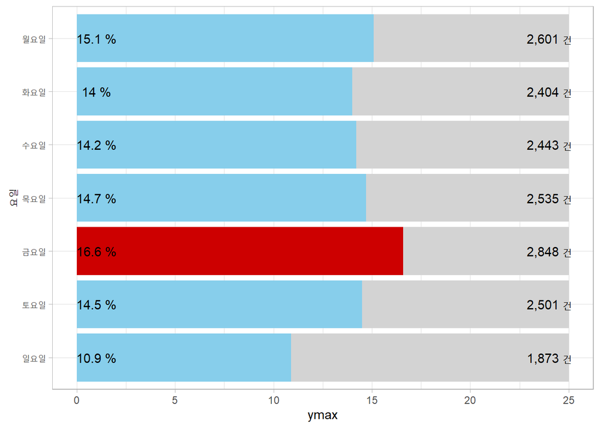

```r
library(scales)

t.data1 %>%
  group_by(요일) %>%
  summarise(n=n(), ratio=round(n()/17205*100,1)) -> out1
out1$요일 = factor(out1$요일,
                 levels=rev(c("월요일","화요일",'수요일',"목요일","금요일","토요일","일요일")))

out1$col = ifelse(out1$ratio>15.5,"red3","skyblue")
out1$ymax = 25

ggplot(out1, aes(x=요일))+
  geom_bar(stat="identity", aes(y=ymax), fill="lightgray")+
  geom_bar(stat="identity", aes(y=ratio), fill=out1$col)+
  geom_text(y=1, aes(label=paste(ratio,"%")))+
  geom_text(y=24, aes(label=paste(comma(n),"건")))+
  coord_flip()+
  ylim(0,25)+
  theme_light()
```

시간대별 사고를 시각화 해보자.

년, 월, 일을 mutate를 이용하여 다시 정리 해보면 다음 코드와 같습니다.

```r
t.data1 %>%
  mutate(year=as.numeric(substr(사고번호,1,4))) %>%
  mutate(mon=as.numeric(substr(사고번호,5,6))) %>%
  mutate(hr=as.numeric(substr(사고일시,nchar(사고일시)-2,nchar(사고일시)-1))) -> t.data2
```

`geom_density`와 `geom_bar`를 이용하면 시간대별 분포를 쉽게 그릴 수 있습니다.

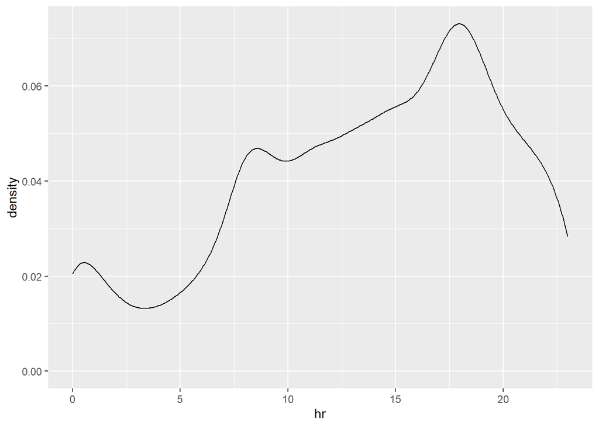

```r
ggplot(t.data2, aes(hr))+ geom_density()
```

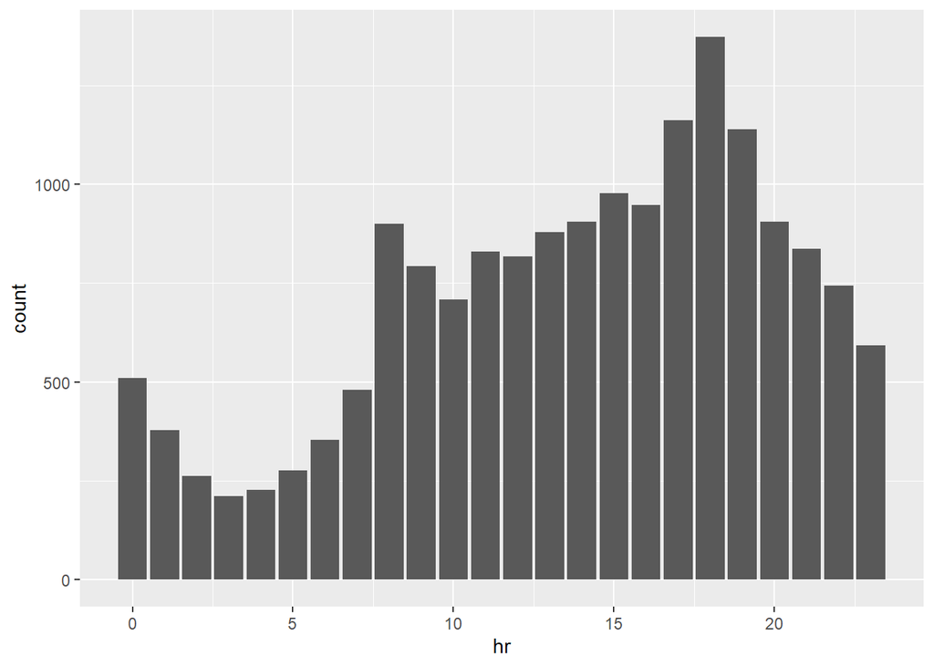

```r
ggplot(t.data2, aes(hr))+ geom_bar()
```

인포그래픽스처럼 2시간단위로 구분하려면 cut 함수를 이용하여 시간대별로 구분하면 됩니다.

```r
cut(t.data2$hr, c(-1,1,3,5,7,9,11,13,15,17,19,21,23)) %>% head
```

```
## [1] (9,11]  (19,21] (19,21] (19,21] (11,13] (13,15]
## 12 Levels: (-1,1] (1,3] (3,5] (5,7] (7,9] (9,11] (11,13] (13,15] ... (21,23]
```

```r
cut(t.data2$hr, seq(-1,23,2)) %>% head
```

```
## [1] (9,11]  (19,21] (19,21] (19,21] (11,13] (13,15]
## 12 Levels: (-1,1] (1,3] (3,5] (5,7] (7,9] (9,11] (11,13] (13,15] ... (21,23]
```

```r
t.data2$hr_c <- cut(t.data2$hr, seq(-1,23,2), seq(0,22,2))
```

이 외에는 기존과 유사하게 코드를 작성하면

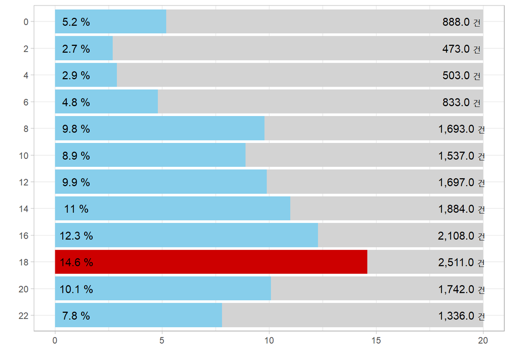

```r
t.data2 %>%
  group_by(hr_c) %>%
  summarise(n=n(), ratio=round(n()/17205*100,1)) -> out2

out2$col = ifelse(out2$ratio>14,"red3","skyblue")
out2$ymax = 20

ggplot(out2, aes(reorder(x=hr_c, -as.numeric(hr_c))))+
  geom_bar(stat="identity", aes(y=ymax), fill="lightgray")+
  geom_bar(stat="identity", fill=out2$col, aes(y=ratio))+
  geom_text(y=1, aes(label=paste(ratio,"%")))+
  geom_text(y=19, aes(label=paste(comma(n),"건")))+
  coord_flip()+
  ylim(0,20)+
  theme_light()+ylab("")+xlab("")
```

### 인적관련 사고 중 법규위반은?

간단하게 그리면

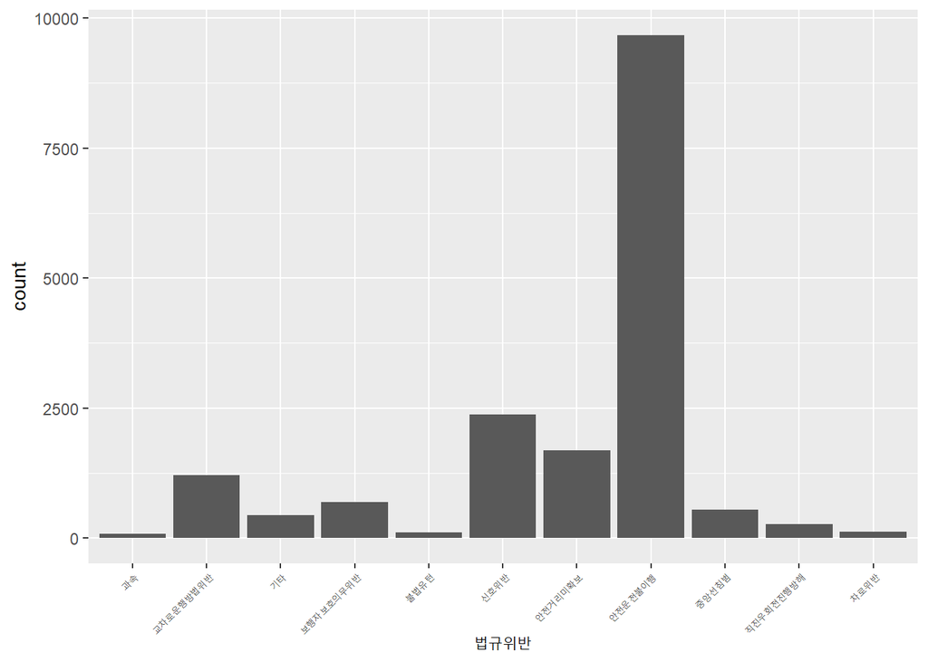

```r
ggplot(t.data1, aes(x=법규위반))+
  geom_bar()+theme(axis.text.x = element_text(angle = 45, size=5, hjust=1))
```

인포그래픽스처럼

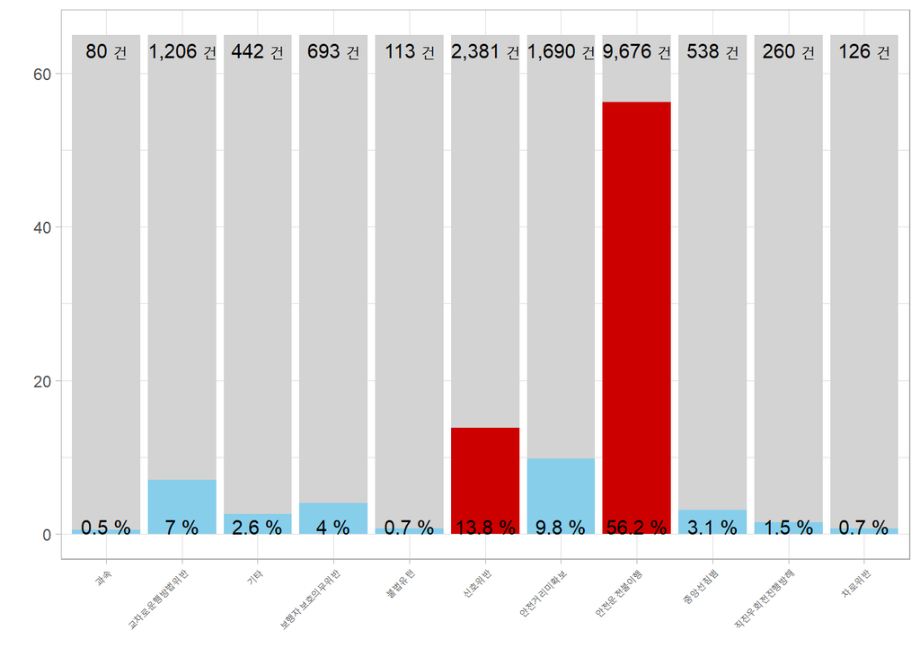

```r
t.data2 %>%
  group_by(법규위반) %>%
  summarise(n=n(), ratio=round(n()/17205*100,1)) -> out3

out3$col = ifelse(out3$ratio>10,"red3","skyblue")
out3$ymax = 65

ggplot(out3, aes(x=법규위반))+
  geom_bar(stat="identity", aes(y=ymax), fill="lightgray")+
  geom_bar(stat="identity", fill=out3$col, aes(y=ratio))+
  geom_text(y=1, aes(label=paste(ratio,"%")))+
  geom_text(y=63, aes(label=paste(comma(n),"건")))+
  ylim(0,65)+
  theme_light()+ylab("")+xlab("")+
  theme(axis.text.x = element_text(angle = 45, size=5, hjust=1))
```

### 가해 운전자 연령별 그림은?

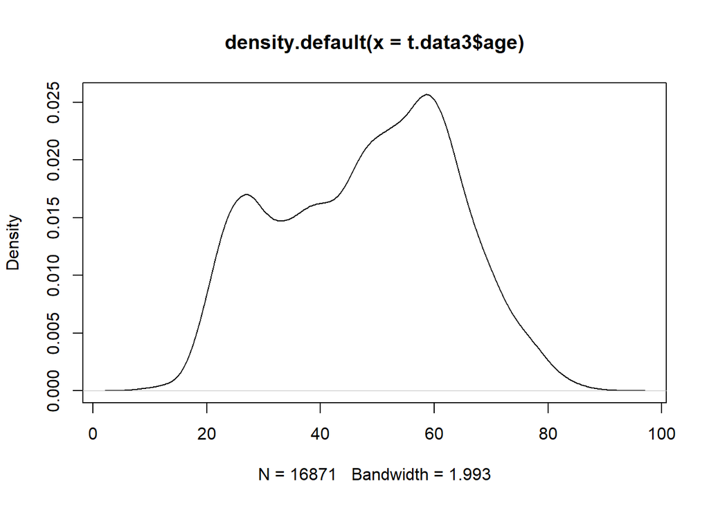

```r
library(stringr)
t.data2$age <- as.numeric(str_extract(t.data2$`가해운전자 연령`,"\\d+"))
t.data3 <- t.data2 %>% filter(!is.na(age))
plot(density(t.data3$age))
```

density와 bar를 이용하여 연령별 그림을 그릴 수 있습니다.

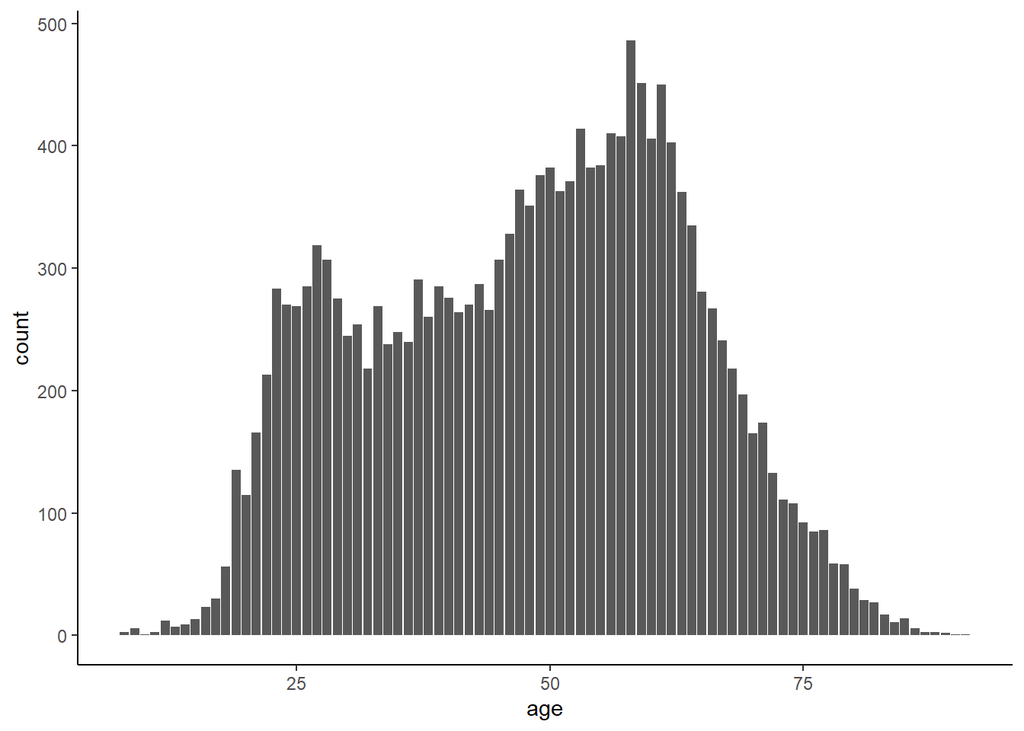

```r
ggplot(t.data3, aes(age))+geom_bar()+theme_classic()
```

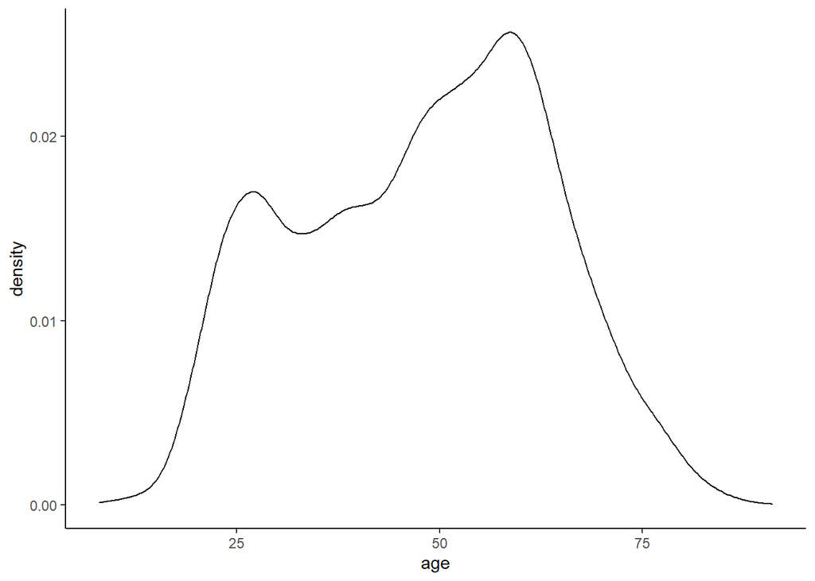

```r
ggplot(t.data3, aes(age))+geom_density()+theme_classic()
```

연령대를 cut함수로 만들면?

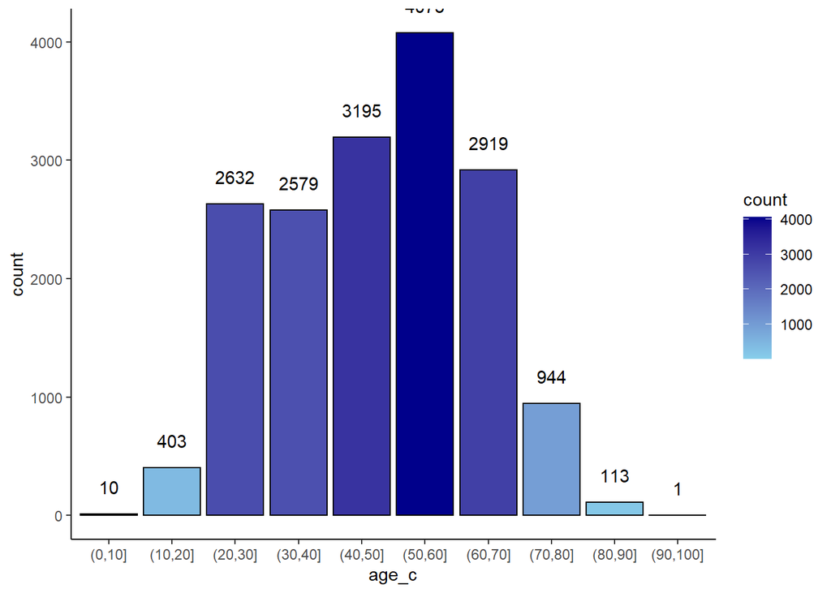

[figure not shown]

```r
t.data3$age_c <- cut(t.data3$age, seq(0,100, by=10))

ggplot(t.data3, aes(x=age_c, fill=..count..))+geom_bar(col="black")+theme_classic()+
  scale_fill_gradient(low="skyblue", high="darkblue")+
  geom_text(aes(label=..count..), stat="count", vjust=-1.5, color="black")
```

차종별 결과는 `가해운전자 차종` 변수를 분석하면 그릴 수 있음

```r
t.data1 %>%
  group_by(`가해운전자 차종`) %>%
  summarise(n=n()) %>%
  arrange(desc(n))
```

```
## # A tibble: 12 x 2
##    `가해운전자 차종`      n
##    <chr>              <int>
##  1 승용               12500
##  2 화물                1685
##  3 승합                1036
##  4 이륜                 942
##  5 기타불명             339
##  6 자전거               324
##  7 원동기               149
##  8 건설기계             102
##  9 특수                  71
## 10 개인형이동수단(PM)    48
## 11 사륜오토바이(ATV)      8
## 12 농기계                 1
```

## 교통사고 보행 사상자

[figure not shown]

보행자 관련 사고를 정리해보자.

보행자 사고는 사고유형이 `차대사람` 이므로 `filter`를 이용하여 차대사람 자료만 선택하자.

이 후 피해사람을 분석하면 교통사고 보행 사상자 자료 분석이 가능하다.

do.call을 이용하여 사고유형을 구분하자.

```r
do.call("rbind",str_split(t.data1$사고유형, " - ", n=2)) %>% data.frame -> new_df
t.data4 <- cbind(t.data1, new_df)
head(t.data4)
```

```
##           사고번호            사고일시   요일                   시군구
## 1 2018010100100186 2018년 1월 1일 10시 월요일 대전광역시 대덕구 오정동
## 2 2018010100100391 2018년 1월 1일 20시 월요일 대전광역시 대덕구 비래동
## 3 2018010100100403 2018년 1월 1일 21시 월요일 대전광역시 대덕구 평촌동
## 4 2018010100100404 2018년 1월 1일 21시 월요일 대전광역시 대덕구 중리동
## 5 2018010200100208 2018년 1월 2일 12시 화요일 대전광역시 대덕구 읍내동
## 6 2018010500100286 2018년 1월 5일 15시 금요일 대전광역시 대덕구 중리동
##       사고내용 사망자수 중상자수 경상자수 부상신고자수          사고유형
## 1     경상사고        0        0        3            0     차대차 - 추돌
## 2 부상신고사고        0        0        0            1   차대사람 - 기타
## 3     경상사고        0        0        2            0 차대차 - 측면충돌
## 4     중상사고        0        1        0            0 차대사람 - 횡단중
## 5     경상사고        0        0        1            0     차대차 - 기타
## 6     경상사고        0        0        2            0 차대차 - 측면충돌
##             법규위반    노면상태 기상상태            도로형태 가해운전자 차종
```

[output cut: 20 more lines]

```r
t.data4 %>%
  filter(X1=="차대사람") -> out5
head(out5)
```

```
##           사고번호            사고일시   요일                     시군구
## 1 2018010100100391 2018년 1월 1일 20시 월요일   대전광역시 대덕구 비래동
## 2 2018010100100404 2018년 1월 1일 21시 월요일   대전광역시 대덕구 중리동
## 3 2018010600100054 2018년 1월 6일 02시 토요일   대전광역시 대덕구 송촌동
## 4 2018010700100118 2018년 1월 7일 09시 일요일   대전광역시 대덕구 중리동
## 5 2018010700100149 2018년 1월 7일 11시 일요일 대전광역시 대덕구 신탄진동
## 6 2018010900100085 2018년 1월 9일 06시 화요일   대전광역시 대덕구 읍내동
##       사고내용 사망자수 중상자수 경상자수 부상신고자수              사고유형
## 1 부상신고사고        0        0        0            1       차대사람 - 기타
## 2     중상사고        0        1        0            0     차대사람 - 횡단중
## 3     경상사고        0        0        2            0       차대사람 - 기타
## 4     중상사고        0        1        0            0     차대사람 - 횡단중
## 5     중상사고        0        1        0            0     차대사람 - 횡단중
## 6     사망사고        1        0        0            0 차대사람 - 차도통행중
##             법규위반         노면상태 기상상태                  도로형태
```

[output cut: 27 more lines]

연령대별 보행사상자

- 피해운전자 연량을 `str_extract`과 `as.numeric`으로 추출하기.
- cut 함수를 이용하여 연령대별로 구분

```r
out5$age<- as.numeric(str_extract(out5$`피해운전자 연령`,"\\d+"))
out5$age_c <- cut(out5$age, c(0,12,20,30,40,50,60,64,100))
```

- 보행자 사고의 사망자 수 : 102
- 보행자 사고의 부상자수 : 3690

sum 함수를 이용하여 계산하면 비율을 구할 수 있습니다.

```r
out5 %>%
  group_by(age_c) %>%
  summarise(death=sum(사망자수), injury=sum(중상자수,경상자수,부상신고자수)) -> out6

out6$death_p = out6$death/sum(out6$death)
out6$injury_p = out6$injury/sum(out6$injury)

out6
```

```
## # A tibble: 8 x 5
##   age_c    death injury death_p injury_p
##   <fct>    <dbl>  <dbl>   <dbl>    <dbl>
## 1 (0,12]       0    220  0        0.0596
## 2 (12,20]      2    319  0.0196   0.0864
## 3 (20,30]      4    624  0.0392   0.169
## 4 (30,40]      3    405  0.0294   0.110
## 5 (40,50]      8    460  0.0784   0.125
## 6 (50,60]     20    593  0.196    0.161
## 7 (60,64]     13    259  0.127    0.0702
## 8 (64,100]    52    810  0.510    0.220
```

이제 막대그림으로 부상자 수와 사망자 수를 동시에 그리면?

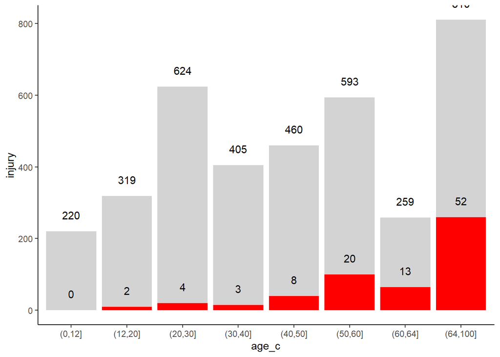

```r
ggplot(data=out6, aes(x=age_c))+
  geom_bar(stat="identity",aes(y=injury), fill="lightgray")+
  geom_bar(stat="identity",aes(y=death*5), fill="red")+
  geom_text(stat="identity", aes(y=injury, label=injury), vjust=-1.5)+
  geom_text(stat="identity", aes(y=death*5, label=death), vjust=-1.5)+
  theme_classic()
```

노령자의 사망비율을 도넛 그림이 더 적절합니다.

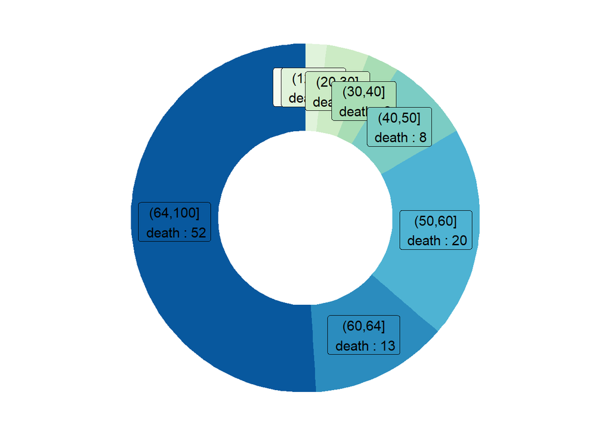

```r
# Compute the cumulative percentages (top of each rectangle)
out6$ymax <- cumsum(out6$death_p)

# Compute the bottom of each rectangle
out6$ymin <- c(0, head(out6$ymax, n=-1))

# Compute label position
out6$labelPosition <- (out6$ymax + out6$ymin) / 2

# Compute a good label
out6$label <- paste0(out6$age_c, "\n death : ", out6$death)

ggplot(data=out6, aes(ymax=ymax, ymin=ymin, xmax=4, xmin=3, fill=age_c)) +
  geom_rect() +
  geom_label(x=3.5, aes(y=labelPosition, label=label), size=4) +
  scale_fill_brewer(palette=4) +
  coord_polar(theta="y") +
  xlim(c(2, 4)) +
  theme_void() +
  theme(legend.position = "none")
```

이때는 `plotly` 패키지를 이용하시면 됩니다.

```r
library(plotly)
out6 %>%
  plot_ly(labels= ~age_c, values=~death_p) %>%
  add_pie(hole=0.6) %>%
  layout(showlegend = T,
         xaxis = list(showgrid = FALSE, zeroline = FALSE, showticklabels = FALSE),
         yaxis = list(showgrid = FALSE, zeroline = FALSE, showticklabels = FALSE))
```

통행중 발생한 사고의 빈도는?

- 막대그림으로 시각화 할 수 있습니다.
- barplot, ggplot, plotly로 모두 표현 가능합니다.
- 비율에 관심이 있다면 도넛그림 또는 원그림이 조금 더 보기 좋습니다.

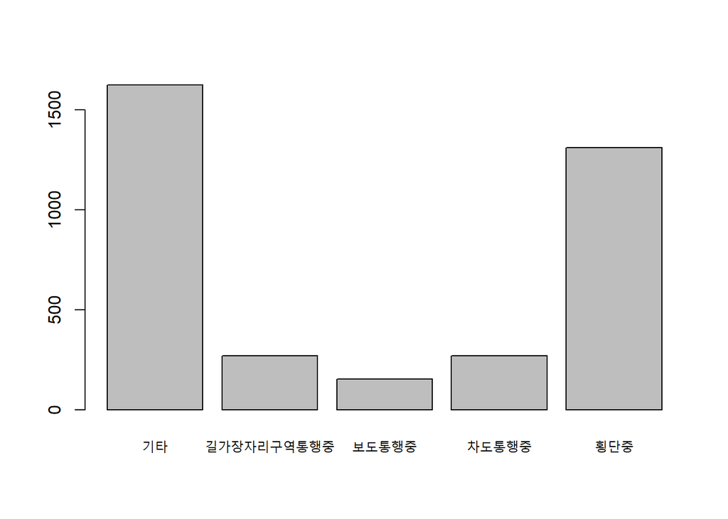

```r
barplot(table(out5$X2))
```

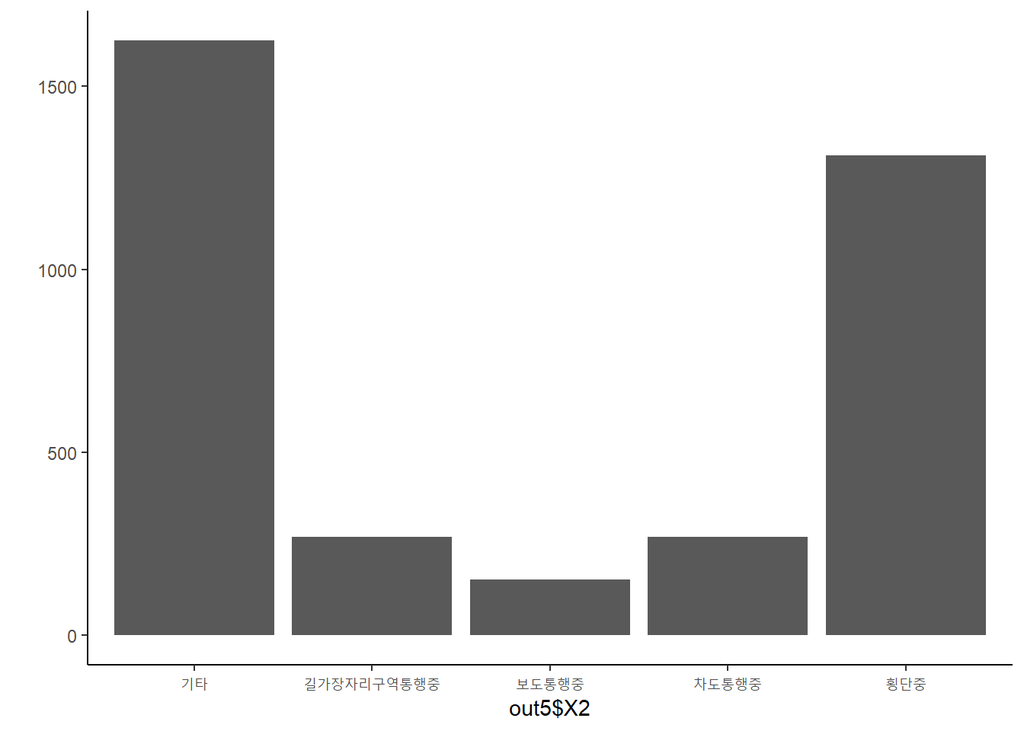

```r
qplot(out5$X2) +theme_classic()
```

```r
data.frame(table(out5$X2)) -> out7
```

```r
out7 %>%
  plot_ly(x=~Var1, y=~Freq, text=~Freq ,type='bar')
```

- 횡단보도 내/외에 해당하는 변수가 없어 추가 그림은 그릴 수 없습니다.

### 시간대별 연령대 사고 시각화

[figure not shown]

out5에 `mutate`를 이용하여 시간 변수를 생성하여 out8에 저장

ifelse를 이용하여 14세 이하를 `children`, 65세 이상을 `senior`

사망자수와 부상자수를 계산하여 out9으로 저장하여 시각화 하면 됩니다.

```r
out5 %>%
  mutate(year=as.numeric(substr(사고번호,1,4))) %>%
  mutate(mon=as.numeric(substr(사고번호,5,6))) %>%
  mutate(hr=as.numeric(substr(사고일시,nchar(사고일시)-2,nchar(사고일시)-1))) -> out8

out8$age_cs <- ifelse(out8$age<=14,"children", ifelse(out5$age<=64,"ordinal","senior"))

out8 %>%
  group_by(age_cs, hr) %>%
  summarise(death=sum(사망자수), injury=sum(중상자수,경상자수,부상신고자수)) -> out9
```

막대도표로 시각화 할때는 한쪽은 음수, 다른 한쪽은 양수로 표현하면 그리기 좋습니다.

```r
out9 %>%
  filter(age_cs != "ordinal") -> out10
out10$death <- ifelse(out10$age_cs=="children", -out10$death, out10$death)
out10$injury <- ifelse(out10$age_cs=="children", -out10$injury, out10$injury)
```

ggplot으로 그림을 그리면 다음과 같습니다.

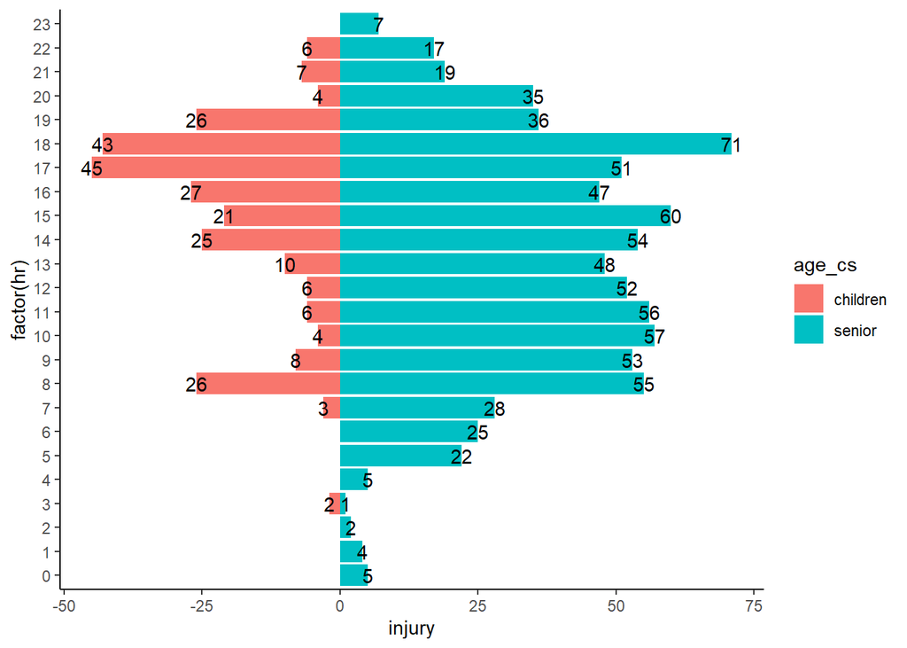

```r
ggplot(out10, aes(x=factor(hr) , y=injury, fill=age_cs))+
  geom_bar(stat="identity")+
  geom_text(aes(label=abs(injury)))+
  theme_classic()+
  coord_flip()
```

scale_x_discrete(limits=rev)를 추가하면 0시부터 23시까지로 정리됩니다.

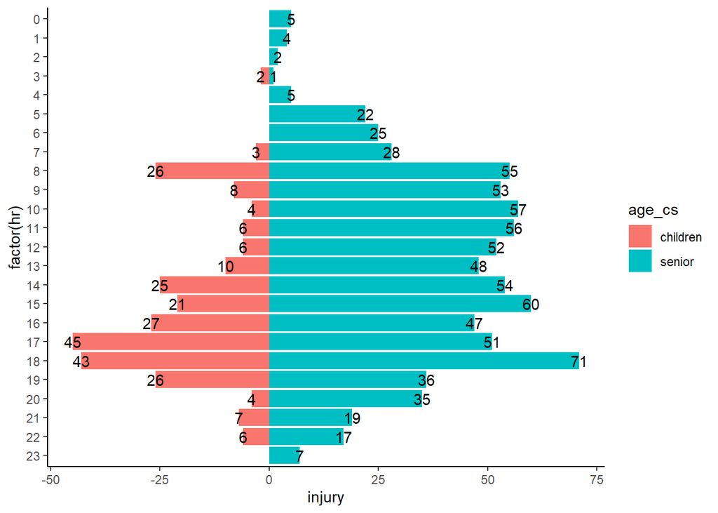

```r
ggplot(out10, aes(x=factor(hr) , y=injury, fill=age_cs))+
  geom_bar(stat="identity")+
  geom_text(aes(label=abs(injury)))+
  theme_classic()+
  scale_x_discrete(limits=rev)+
  coord_flip()
```

## 고령자 교통사고의 주요 특성은?

[figure not shown]

두가지 방향을 모두 분석하실 수 있습니다.

- 가해운전자 연령이 65이상을 추출하여 분석
- 피해운전자 연령이 65이상을 추출하여 분석
- `filter`와 `table`가 주로 사용되며 필요에 따라 `substr`이 이용됩니다.

## 어린이 교통사고의 주요 특성은?

[figure not shown]

- 피해운전자 연령이 14세 이하를 추출하여 분석
- `filter`와 `table`가 주로 사용되며 필요에 따라 `substr`이 이용됩니다.